# CS559_Project2_SupervisedLearning_Classification

## Project 2 - Supervised Learning - Gradiant Descent and Classification

### Due: 4/9/2021 Frinday 11:59 PM

### Task

This project is broadly breakinto two parts:

1. Gradient Descent Implementation - the task is to implement the gradien descent function to find all possible local mamina and gloabl minimum coordinates.
2. Wine Quality Classifiaction Implementation - the task is to implement three classifiers, KNN, LDA, and Logistic Regresion, to classify the quality of red wine using a given data `winequality-red.csv`.

### Descriptions & Rules

1. All work must be your own. Any evidence of copying, collaborating, and cheating will result 0.
2. This project does not require a report. However, all work and results must be discussed - simply answering or stating results is not acceptable.
3. **The project will not allow any extenstions** - except a case of health and other emergencies. You must submit the project as incompletion if you do not finish on time.
4. You must submit the **jupyter notebook** file and the **exported HTML** file.
5. All codes must be excutable - if the code does not work, you will get 0 for that particular code.

### Gradient Descent Implementation.

We are going to implement a standard gradient decent optimization function `my_GradDes(x,y,z,theta,learning_rate,iteration)` to find all possible local maxima and global maximum coordinates.

Data Set: `P2_1.csv` has four features. We have $x=(-4.0,4.0)$ and $y=(-4.0,4.0)$, the true $z$ value is a function of $x$ and $y$, $z=f(x,y)$, and $z_pred$ which is a predicted value of $z$. Below a 3-D plot is povided.

Requirement:

1. The cost function: $J(\theta)=\frac{1}{2m}\sum_{i=1}^{m}(h(\theta)^i-y^i))^2$
2. Gradient: $\frac{\partial J(\theta)}{\partial \theta_j}=\frac{1}{m}\sum_{i=1}^{m}(h(\theta)^i-y^i)).X_j^i$

where $m=$number of observation.

Task:

1. Test with the learning rate $\eta=[0.01, 0.05, 0.1, 1]$.

Required Result: For each $\eta$, report

1. Iteration #
2. Did it overshoot?
3. Total number of local minima
4. The coordinates ($x,y$) for all local minima and global mimimum

Points:

- Code: 25 points
- Test: 5 points
- Answers: 20 points

[figure not shown]

```python
import pandas as pd
import matplotlib.pyplot as plt
from matplotlib import cm
from matplotlib.ticker import LinearLocator, FormatStrFormatter
from mpl_toolkits.mplot3d import Axes3D

import warnings
warnings.filterwarnings('ignore')

%matplotlib notebook
df = pd.read_csv('P2_1.csv')

fig = plt.figure()
ax = Axes3D(fig)
ax.plot_trisurf(df.x, df.y, df.z, cmap=cm.jet, linewidth=0.2)
plt.xlabel("x")
plt.ylabel('y')
plt.show()
```

```python
# towards data science example code for 2d normal gradient descent
x = 2*np.random.rand(100,1)
y = 4 + 3*x + np.random.randn(100,1)


def cal_cost(theta,X,y):
    '''
    Calculates the cost for given X and Y. The following shows an example of a single dimensional x

    theta = vector of thetas
    x = Row of X's np.zeros((2,j))
    y = actual y's np.zeros((2,1))

    where:
        j is the number of features
    '''
    m = len(y)

    predictions = X.dot(theta)
    cost = (1/2*m) * np.sum(np.square(predictions-y))
    return cost


# 2D example code from medium article:
def gradient_descent(x,y,theta,learning_rate=0.01,iterations=100):
    '''
    x = Matrix of X with added bias units
    y = vector of Y
    theta = vector of thetas np.random.randn(j,1)
    learning_rate
    iterations = no of iterations

    Returns the final theta vector and array of cost history over number of iterations
    '''
    m = len(y)
    cost_history = np.zeros(iterations)
    theta_history = np.zeros((iterations,2))

    for it in range(iterations):

        prediction = np.dot(x, theta)

        theta = theta - (1/m) * learning_rate * (x.T.dot((prediction - y)))
        theta_history[it,:] = theta.T
        cost_history[it] = cal_cost(theta,x,y)
    return theta, cost_history, theta_history
```

Notes:

Based on the above plot, we realize that there are 4 separate regions, each that can be represented by a guassian function,

f(x,y)=A(exp(−((x−a)^2/2σx+(y−b)^2/2σy)))

And with gradient descent, we are supposed to be able to find A and B such that this gaussian function best fits our data.

I'm thinking that the idea is that we need to use the cost function cal_cost just like above, but instead of simply doing h(theta) or like f(x) - y {which is just like X.dot(theta)), we need to substitute f(x) with the gaussian function. For that, we need to find the gradient of the gaussian function and find the best a and b so that way we can then have our f(x), which will give us our predictor value.

After we have our predictor value, we can just simply use a similar method as above.

```python
import numpy as np
import random
# region 1: x>= 1, y < -1
df1 = df[(df.x >= 1) & (df.y <= -1)]
x1 = df1['x'].values.reshape((df1['x'].size,1))
y1 = df1['y'].values.reshape((df1['y'].size,1))
z1 = df1['z'].values.reshape((df1['z'].size,1))

df2 = df[(df.x <= 0) & (df.x >= -2) & (df.y <= 0)]
x2 = df2['x'].values.reshape((df2['x'].size,1))
y2 = df2['y'].values.reshape((df2['y'].size,1))
z2 = df2['z'].values.reshape((df2['z'].size,1))

df3 = df[(df.x <= 1) & (df.x >= -2) & (df.y >= 1)]
x3 = df3['x'].values.reshape((df3['x'].size,1))
y3 = df3['y'].values.reshape((df3['y'].size,1))
z3 = df3['z'].values.reshape((df3['z'].size,1))

df4 = df[(df.x >= 1) & (df.y <= 1)]
x4 = df4['x'].values.reshape((df4['x'].size,1))
y4 = df4['y'].values.reshape((df4['y'].size,1))
z4 = df4['z'].values.reshape((df4['z'].size,1))

print(x1.size, y1.size, z1.size)
print(x2.size, y2.size, z2.size)
print(x3.size, y3.size, z3.size)
print(x4.size, y4.size, z4.size)
```

```
119 119 119
273 273 273
255 255 255
310 310 310
```

```python
# The gradient gaussian function
import numpy as np
import math

def gaussian_function(array, theta):
    '''
    array = the array of inputs
    theta = theta value, some random number

    calculates a prediction value, using the gaussian function on each of the array values, and
    returns array res, an array of identical size to the inputs that contains a prediction for each input, accordingly
    '''
    res = np.array([])
    std = np.std(array)
    for i in range(array.size):
        res = np.append(res, math.exp(-(np.square(array[i] - theta) / (2 * std))))
    return res
```

```python
### Code Starts Here
def my_Gradient(x,y,z,theta,learning_rate,iteration):
    overshoot = False
    m = len(z)
    theta_history = np.zeros((iteration,2))
    std_x = np.std(x)
    std_y = np.std(y)

    boundary_x_lo = np.min(x)
    boundary_x_hi = np.max(x)
    boundary_y_lo = np.min(y)
    boundary_y_hi = np.max(y)

    #print(boundary_x_lo)
    #print(boundary_x_hi)
    #print(boundary_y_lo)
    #print(boundary_y_hi)

    # make sure to set boundaries
    # after
    for i in range(iteration):
        '''
        theta[0] = theta array x values
        theta[1] = theta array y values
        '''
        x_pred = gaussian_function(x, theta[0]).reshape((x.size, 1))
        y_pred = gaussian_function(y, theta[1]).reshape((y.size, 1))

        x_comp = (x_pred - z)
        y_comp = (y_pred - z)

        x_grad =  (x_pred.T.dot(x_comp))
        y_grad =  (y_pred.T.dot(y_comp))


        theta_x = theta[0] - (1/m) * learning_rate * x_grad
        theta_y = theta[1] - (1/m) * learning_rate * y_grad

        theta_history[i, :] = theta.T

        if(theta_x > boundary_x_hi or theta_x < boundary_x_lo or theta_y > boundary_y_hi or theta_y < boundary_y_lo):
            #print("this did not work right")
            overshoot = True
            break
        else:
            theta[0] = theta[0] - (1/m) * learning_rate * x_grad
            theta[1] = theta[1] - (1/m) * learning_rate * y_grad
           # theta_history[i, :] = theta.T
    return theta, theta_history, overshoot
```

Testing the gradient descent with 100 iterations, learning rate = 0.01

```python
theta_region1 = np.array([random.uniform(np.min(x1),np.max(x1)),random.uniform(np.min(y1),np.max(y1))])
t1, t_h1, overshoot1 = my_Gradient(x1, y1, z1, theta_region1, 0.01, 100)
print(t1)
print("Overshoot?", overshoot1)
print()

theta_region2 = np.array([random.uniform(np.min(x2),np.max(x2)),random.uniform(np.min(y2),np.max(y2))])
t2, t_h2, overshoot2 = my_Gradient(x2, y2, z2, theta_region2, 0.01, 100)
print(t2)
print("Overshoot?", overshoot2)
print()

theta_region3 = np.array([random.uniform(np.min(x3),np.max(x3)),random.uniform(np.min(y3),np.max(y3))])
t3, t_h3, overshoot3 = my_Gradient(x3, y3, z3, theta_region3, 0.01, 100)
print(t3)
print("Overshoot?", overshoot3)
print()

theta_region4 = np.array([random.uniform(np.min(x4),np.max(x4)),random.uniform(np.min(y4),np.max(y4))])
t4, t_h4, overshoot4 = my_Gradient(x4, y4, z4, theta_region4, 0.01, 100)
print(t4)
print("Overshoot?", overshoot4)
print()
```

```
[ 2.78953222 -3.52540035]
Overshoot? False

[-1.77903169 -1.92657011]
Overshoot? False

[-0.94357429  1.00734934]
Overshoot? True

[ 1.44186032 -0.35372734]
Overshoot? False
```

Testing the gradient descent with 100 iterations, learning rate = 0.05

```python
theta_region1 = np.array([random.uniform(np.min(x1),np.max(x1)),random.uniform(np.min(y1),np.max(y1))])
t1, t_h1, overshoot1 = my_Gradient(x1, y1, z1, theta_region1, 0.05, 100)
print(t1)
print("Overshoot?", overshoot1)
print()

theta_region2 = np.array([random.uniform(np.min(x2),np.max(x2)),random.uniform(np.min(y2),np.max(y2))])
t2, t_h2, overshoot2 = my_Gradient(x2, y2, z2, theta_region2, 0.05, 100)
print(t2)
print("Overshoot?", overshoot2)
print()

theta_region3 = np.array([random.uniform(np.min(x3),np.max(x3)),random.uniform(np.min(y3),np.max(y3))])
t3, t_h3, overshoot3 = my_Gradient(x3, y3, z3, theta_region3, 0.05, 100)
print(t3)
print("Overshoot?", overshoot3)
print()

theta_region4 = np.array([random.uniform(np.min(x4),np.max(x4)),random.uniform(np.min(y4),np.max(y4))])
t4, t_h4, overshoot4 = my_Gradient(x4, y4, z4, theta_region4, 0.05, 100)
print(t4)
print("Overshoot?", overshoot4)
print()
```

```
[ 1.03435044 -3.31580257]
Overshoot? True

[-1.97877408 -2.93139182]
Overshoot? True

[-1.95015316  1.06036159]
Overshoot? True

[ 1.01732638 -3.00226512]
Overshoot? True
```

Testing the gradient descent with 100 iterations, learning rate = 0.1

```python
theta_region1 = np.array([random.uniform(np.min(x1),np.max(x1)),random.uniform(np.min(y1),np.max(y1))])
t1, t_h1, overshoot1 = my_Gradient(x1, y1, z1, theta_region1, 0.1, 100)
print(t1)
print("Overshoot?", overshoot1)
print()

theta_region2 = np.array([random.uniform(np.min(x2),np.max(x2)),random.uniform(np.min(y2),np.max(y2))])
t2, t_h2, overshoot2 = my_Gradient(x2, y2, z2, theta_region2, 0.1, 100)
print(t2)
print("Overshoot?", overshoot2)
print()

theta_region3 = np.array([random.uniform(np.min(x3),np.max(x3)),random.uniform(np.min(y3),np.max(y3))])
t3, t_h3, overshoot3 = my_Gradient(x3, y3, z3, theta_region3, 0.1, 100)
print(t3)
print("Overshoot?", overshoot3)
print()

theta_region4 = np.array([random.uniform(np.min(x4),np.max(x4)),random.uniform(np.min(y4),np.max(y4))])
t4, t_h4, overshoot4 = my_Gradient(x4, y4, z4, theta_region4, 0.1, 100)
print(t4)
print("Overshoot?", overshoot4)
print()
```

```
[ 1.42012049 -3.75008918]
Overshoot? True

[-1.97038926 -2.71012727]
Overshoot? True

[-1.96626411  1.10281376]
Overshoot? True

[ 1.20492079 -3.75467747]
Overshoot? True
```

Testing the gradient descent with 100 iterations, learning rate = 1

```python
theta_region1 = np.array([random.uniform(np.min(x1),np.max(x1)),random.uniform(np.min(y1),np.max(y1))])
t1, t_h1, overshoot1 = my_Gradient(x1, y1, z1, theta_region1, 1, 100)
print(t1)
print("Overshoot?", overshoot1)
print()

theta_region2 = np.array([random.uniform(np.min(x2),np.max(x2)),random.uniform(np.min(y2),np.max(y2))])
t2, t_h2, overshoot2 = my_Gradient(x2, y2, z2, theta_region2, 1, 100)
print(t2)
print("Overshoot?", overshoot2)
print()

theta_region3 = np.array([random.uniform(np.min(x3),np.max(x3)),random.uniform(np.min(y3),np.max(y3))])
t3, t_h3, overshoot3 = my_Gradient(x3, y3, z3, theta_region3, 1, 100)
print(t3)
print("Overshoot?", overshoot3)
print()

theta_region4 = np.array([random.uniform(np.min(x4),np.max(x4)),random.uniform(np.min(y4),np.max(y4))])
t4, t_h4, overshoot4 = my_Gradient(x4, y4, z4, theta_region4, 1, 100)
print(t4)
print("Overshoot?", overshoot4)
print()
```

```
[ 1.45619871 -2.89827502]
Overshoot? True

[-1.94270707 -1.12413351]
Overshoot? True

[-1.63554082  3.54651975]
Overshoot? True

[ 1.37311258 -2.60532259]
Overshoot? True
```

Learning rate = 0.05  
Iteration #: 100  
Overshoot?: Yes  
Local minima count: 3  
Local minima:  
[ 1.03435044 -3.31580257]  
[-1.97877408 -2.93139182]  
[ 1.01732638 -3.00226512]  
Global minima:  
[-1.95015316 1.06036159]

Learning rate = 0.1  
Iteration #: 100  
Overshoot?: Yes  
Local minima count: 3  
Local minima:  
[ 1.42012049 -3.75008918]  
[-1.97038926 -2.71012727]  
[ 1.20492079 -3.75467747]  
Global minima:  
[-1.96626411 1.10281376]

Learning rate = 1  
Iteration #: 100  
Overshoot?: Yes  
Local minima count: 3  
Local minima:  
[ 1.45619871 -2.89827502]  
[-1.94270707 -1.12413351]  
[ 1.37311258 -2.60532259]  
Global minima:  
[-1.63554082 3.54651975]

### Classification - Wine Quality

In the given data, `winequality-red.csv`,there are 12 features and the target is “quality”. You are going to implement three classifiers to classify the wine quality.

A. Exploratory Data Analysis: (10 pts)

- a. Find missing value features and impute the value using mean, median, and 0.
- b. Make histograms and determine which method in A-a is the most appropriate.
- c. The wine quality is rated from 3 to 8. Categorize the quality to be a binary categorical data as good and bad.

```python
import pandas as pd
import matplotlib.pyplot as plot
import numpy as np
import copy

DF = pd.read_csv('winequality-red.csv')
pd.options.display.max_columns = None
```

```python
DF.describe()
```

|  | fixed acidity | volatile acidity | citric acid | residual sugar | chlorides | free sulfur dioxide | total sulfur dioxide | density | pH | sulphates | alcohol | quality |
| --- | --- | --- | --- | --- | --- | --- | --- | --- | --- | --- | --- | --- |
| count | 1580.000000 | 1567.000000 | 1429.000000 | 1561.000000 | 1548.000000 | 1519.000000 | 1542.000000 | 1541.000000 | 1565.000000 | 1538.000000 | 1577.000000 | 1599.000000 |
| mean | 8.311899 | 0.528507 | 0.292169 | 2.538117 | 0.087380 | 15.923634 | 46.459792 | 0.996736 | 3.311118 | 0.656762 | 10.417998 | 5.636023 |
| std | 1.739155 | 0.179772 | 0.183498 | 1.421287 | 0.047511 | 10.435862 | 32.914107 | 0.001880 | 0.154230 | 0.170419 | 1.059191 | 0.807569 |
| min | 4.600000 | 0.120000 | 0.010000 | 0.900000 | 0.012000 | 1.000000 | 6.000000 | 0.990070 | 2.740000 | 0.330000 | 8.400000 | 3.000000 |
| 25% | 7.100000 | 0.390000 | 0.130000 | 1.900000 | 0.070000 | 7.000000 | 22.000000 | 0.995600 | 3.210000 | 0.550000 | 9.500000 | 5.000000 |
| 50% | 7.900000 | 0.520000 | 0.280000 | 2.200000 | 0.079000 | 14.000000 | 38.000000 | 0.996750 | 3.310000 | 0.620000 | 10.200000 | 6.000000 |
| 75% | 9.200000 | 0.640000 | 0.440000 | 2.600000 | 0.090000 | 21.500000 | 62.000000 | 0.997800 | 3.400000 | 0.730000 | 11.100000 | 6.000000 |
| max | 15.900000 | 1.580000 | 1.000000 | 15.500000 | 0.611000 | 72.000000 | 289.000000 | 1.003690 | 4.010000 | 2.000000 | 14.900000 | 8.000000 |

```python
DF.std()
```

```
fixed acidity            1.739155
volatile acidity         0.179772
citric acid              0.183498
residual sugar           1.421287
chlorides                0.047511
free sulfur dioxide     10.435862
total sulfur dioxide    32.914107
density                  0.001880
pH                       0.154230
sulphates                0.170419
alcohol                  1.059191
quality                  0.807569
dtype: float64
```

```python
DF.mean()
```

```
fixed acidity            8.311899
volatile acidity         0.528507
citric acid              0.292169
residual sugar           2.538117
chlorides                0.087380
free sulfur dioxide     15.923634
total sulfur dioxide    46.459792
density                  0.996736
pH                       3.311118
sulphates                0.656762
alcohol                 10.417998
quality                  5.636023
dtype: float64
```

```python
DF.median()
```

```
fixed acidity            7.90000
volatile acidity         0.52000
citric acid              0.28000
residual sugar           2.20000
chlorides                0.07900
free sulfur dioxide     14.00000
total sulfur dioxide    38.00000
density                  0.99675
pH                       3.31000
sulphates                0.62000
alcohol                 10.20000
quality                  6.00000
dtype: float64
```

```python
DF_std = copy.deepcopy(DF)
DF_mean = copy.deepcopy(DF)
DF_median = copy.deepcopy(DF)
```

```python
#print(DF_std['fixed acidity'][0])

# Replaces DF_std null values with the column's respective std's
print(DF_std.isna().sum().sum())
for i in DF_std:
    DF_std[i].fillna(value=DF_std[i].std(), inplace=True)
print(DF_std.isna().sum().sum())

# Replaces DF_mean null values with the column's respective means
print(DF_mean.isna().sum().sum())
for i in DF_mean:
    DF_mean[i].fillna(value=DF_mean[i].mean(), inplace=True)
print(DF_mean.isna().sum().sum())

# Replaces DF_median null values with the column's respective medians
print(DF_median.isna().sum().sum())
for i in DF_median:
    DF_median[i].fillna(value=DF_median[i].median(), inplace=True)
print(DF_median.isna().sum().sum())
```

```
622
0
622
0
622
0
```

```
array([[<AxesSubplot:title={'center':'fixed acidity'}>,
        <AxesSubplot:title={'center':'volatile acidity'}>,
        <AxesSubplot:title={'center':'citric acid'}>],
       [<AxesSubplot:title={'center':'residual sugar'}>,
        <AxesSubplot:title={'center':'chlorides'}>,
        <AxesSubplot:title={'center':'free sulfur dioxide'}>],
       [<AxesSubplot:title={'center':'total sulfur dioxide'}>,
        <AxesSubplot:title={'center':'density'}>,
        <AxesSubplot:title={'center':'pH'}>],
       [<AxesSubplot:title={'center':'sulphates'}>,
        <AxesSubplot:title={'center':'alcohol'}>,
        <AxesSubplot:title={'center':'quality'}>]], dtype=object)
```

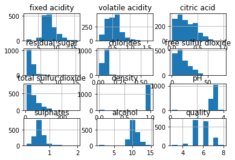

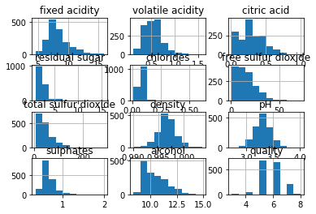

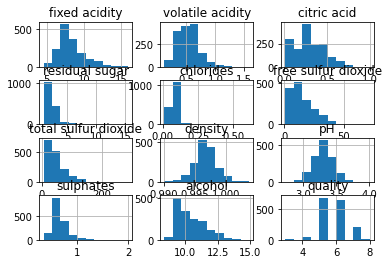

```python
DF_std.hist()
DF_mean.hist()
DF_median.hist()
```

Based on the histograms above, it seems that using the median to fill in the missing data creates the best/most normally distributed histograms. Therefore, I will be using DF_median.

```python
# Range is 3-8, so 3,4,5 is bad, 6,7,8 is good
# [3,6), [6, 8]
DF_median_GB = copy.deepcopy(DF_median)
good_or_bad = []

for x in DF['quality']:
    if(x < 6):
        good_or_bad.append('bad')
    if(x >= 6):
        good_or_bad.append('good')
DF_median_GB['Good or Bad'] = good_or_bad
```

```python
DF_median_GB.head()
```

|  | fixed acidity | volatile acidity | citric acid | residual sugar | chlorides | free sulfur dioxide | total sulfur dioxide | density | pH | sulphates | alcohol | quality | Good or Bad |
| --- | --- | --- | --- | --- | --- | --- | --- | --- | --- | --- | --- | --- | --- |
| 0 | 7.4 | 0.70 | 0.28 | 1.9 | 0.076 | 11.0 | 34.0 | 0.9978 | 3.51 | 0.56 | 9.4 | 5 | bad |
| 1 | 7.8 | 0.88 | 0.28 | 2.6 | 0.098 | 25.0 | 67.0 | 0.9968 | 3.20 | 0.68 | 9.8 | 5 | bad |
| 2 | 7.8 | 0.76 | 0.04 | 2.3 | 0.092 | 15.0 | 54.0 | 0.9970 | 3.26 | 0.65 | 9.8 | 5 | bad |
| 3 | 11.2 | 0.28 | 0.56 | 1.9 | 0.075 | 17.0 | 60.0 | 0.9980 | 3.16 | 0.58 | 9.8 | 6 | good |
| 4 | 7.4 | 0.70 | 0.28 | 1.9 | 0.076 | 11.0 | 34.0 | 0.9978 | 3.51 | 0.56 | 9.4 | 5 | bad |

B. Implement KNN function, my_KNN, to classify the good and bad wine quality. (10 pts)

```python
import numpy as np
from scipy.stats import mode

# calculates the eucliedian distance
def eucledian_df(df1, df2):
    fixed_acidity_dist = ((df1['fixed acidity'] - df2['fixed acidity'])**2)
    volatile_acidity_dist = ((df1['volatile acidity'] - df2['volatile acidity'])**2)
    citric_acid_dist = ((df1['citric acid'] - df2['citric acid'])**2)
    residual_sugar_dist = ((df1['residual sugar'] - df2['residual sugar'])**2)
    chlorides_dist = ((df1['chlorides'] - df2['chlorides'])**2)
    free_sulfur_dioxide_dist = (((df1['free sulfur dioxide'] - df2['free sulfur dioxide'])**2))
    total_sulfur_dioxide_dist = (((df1['total sulfur dioxide'] - df2['total sulfur dioxide'])**2))
    density_dist = (((df1['density'] - df2['density'])**2))
    pH_dist = (((df1['pH'] - df2['pH'])**2))
    sulphates_dist = (((df1['sulphates'] - df2['sulphates'])**2))
    alcohol_dist = (((df1['alcohol'] - df2['alcohol'])**2))
    quality_dist = (((df1['quality'] - df2['quality'])**2))

    dist = np.sqrt(fixed_acidity_dist + volatile_acidity_dist + citric_acid_dist + residual_sugar_dist +
                             chlorides_dist + free_sulfur_dioxide_dist + density_dist + pH_dist +
                                sulphates_dist + alcohol_dist + quality_dist)
    #dist = np.sqrt(quality_dist)
    return dist

# gets the num_neighbors (k) nearest neighbors
def get_neighbors(training_data, test_df, num_neighbors):
    distances = list();

    for i in range(training_data.shape[0]):
        training_data_row = training_data.loc[i]
        test_data_row = test_df.loc[0]

        dist = eucledian_df(training_data_row, test_data_row)
        distances.append(((training_data_row), dist))
    distances.sort(key=lambda tup: tup[1])
    neighbors = list()
    for i in range(num_neighbors):
        neighbors.append(distances[i][0])
    return neighbors

# prediction classifier
def my_KNN(training_data, test_df, num_neighbors):
    neighbors = get_neighbors(training_data, test_df, num_neighbors)
    good_count = 0
    bad_count = 0
    for x in neighbors:
        if(x['Good or Bad'] == 'good'):
            good_count += 1
        if(x['Good or Bad'] == 'bad'):
            bad_count += 1

    if(good_count > bad_count):
        return 'good'
    if(bad_count > good_count):
        return 'bad'
```

```python
# Quality: 3,4,5 bad, 6,7,8 good
# Modify this to input different wines!
test_data_knn = [[
              6.5,      # fixed acidity
              0.8,      # volatile acidity
              0.4,      # citric acid
              2.5,      # residual sugar
              0.06,     # chlorides
              15.0,     # free sulfur dioxide
              47.0,     # total sulfur dioxide
              0.9982,   # density
              4.54,     # pH
              0.49,     # sulphates
              9.5,      # alcohol
              6         # quality
             ]]
test_data_columns_knn = ['fixed acidity', 'volatile acidity', 'citric acid', 'residual sugar', 'chlorides', 'free sulfur dioxide',
                        'total sulfur dioxide', 'density', 'pH', 'sulphates', 'alcohol', 'quality']
test_wine_knn = pd.DataFrame(test_data_knn, columns = test_data_columns_knn)

prediction_knn = my_KNN(DF_median_GB, test_wine_knn, 3)
print('Inputted wine is predicted to be', prediction_knn)
```

```
Inputted wine is predicted to be good
```

C. Implement LDA, my_LDA, to classify the good and bad wine quality. (15 pts)

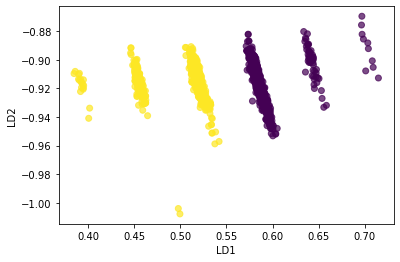

```python
# Code inspired from this article:
# https://www.mygreatlearning.com/blog/linear-discriminant-analysis-or-lda/
from sklearn import preprocessing
import matplotlib.pyplot as plt

def my_LDA(df):
    between_class_feature_means = pd.DataFrame(columns=['good','bad'])

    for col,row in df.groupby('Good or Bad'):
        between_class_feature_means[col] = row.mean()

    within_class_scatter_matrix = np.zeros((12,12))

    for col,rows in df.groupby('Good or Bad'):
        rows = rows.drop(['Good or Bad'],axis=1)
        s=np.zeros((12,12))

        for index,rows in rows.iterrows():
            x = rows.values.reshape(12,1)
            mc = between_class_feature_means[col].values.reshape(12,1)
            s+=(x-mc).dot((x-mc).T)

        within_class_scatter_matrix+=s

    feature_means = df.mean()
    between_class_scatter_matrix = np.zeros((12,12))

    for i in between_class_feature_means:
        n = len(df.loc[df['Good or Bad'] == i].index)
        mc = between_class_feature_means[i].values.reshape(12,1)
        m = feature_means.values.reshape(12,1)
        between_class_scatter_matrix += n*(mc-m).dot((mc-m).T)

    eig_val,eig_vec = np.linalg.eig(np.linalg.inv(within_class_scatter_matrix).dot(between_class_scatter_matrix))

    pairs = [(np.abs(eig_val[i]),eig_vec[:,i]) for i in range(len(eig_val))]
    pairs = sorted(pairs,key=lambda x: x[0], reverse=True)

    eig_val_sums = sum(eig_val)

    matrix_W = np.hstack((pairs[0][1].reshape(12,1),pairs[1][1].reshape(12,1))).real
    features = df.drop(['Good or Bad'],axis=1)
    X_lda = np.array(features.dot(matrix_W))

    return X_lda

lda = my_LDA(DF_median_GB)

le = preprocessing.LabelEncoder()
y = le.fit_transform(DF_median_GB['Good or Bad'])

plt.xlabel('LD1')
plt.ylabel('LD2')
plt.scatter(lda[:,0],lda[:,1],alpha=0.7, c=y)
plt.show()
```

```python
test_data_lda = [[
              6.5,      # fixed acidity
              0.8,      # volatile acidity
              0.4,      # citric acid
              2.5,      # residual sugar
              0.06,     # chlorides
              15.0,     # free sulfur dioxide
              47.0,     # total sulfur dioxide
              0.9982,   # density
              4.54,     # pH
              0.49,     # sulphates
              9.5,      # alcohol
              6         # quality
             ]]


lda = my_LDA(DF_median_GB)

le = preprocessing.LabelEncoder()
y = le.fit_transform(DF_median_GB['Good or Bad'])
```

D. Implement Logistic Regression, my_LogisticRegression, to classify the wine quality. (20 pts)

```python
def dataNormalization(x):
    # Code from this article
    # https://medium.com/@toyg_68342/red-wine-quality-classification-with-logistic-regression-8cbe6aa12b67
    """
    Standard deviation normalization was performed.
    :param x: x_train
    :return: normalizedValues
    """

    lengthOfSelectedData = len(x)
    sumOfSelectedData = sum(x)
    mean = sumOfSelectedData / lengthOfSelectedData

    average = sum(x) * 1.0 / len(x)
    variance = list(map(lambda x: (x - average) ** 2, x))
    std = (sum(variance) * 1.0 / len(variance)) ** 0.5
    x_train_mean = mean
    x_train_std = std
    normalizedValues = (x - x_train_mean) / x_train_std

    return normalizedValues

def sigmoid():
    # Code from this article:
    # https://medium.com/@toyg_68342/red-wine-quality-classification-with-logistic-regression-8cbe6aa12b67
    """
    Sigmoid function is calculated
    :return: sigma
    """
    func = lambda x: 1 / (1 + np.exp(-x))
    sigma = lambda y: list(map(func, y))
    return sigma

def my_LogisticRegression(X,Y):
    # Code from this article:
    # https://medium.com/@toyg_68342/red-wine-quality-classification-with-logistic-regression-8cbe6aa12b67
    iterations = 100
    lrate = 0.1
    sigma  = sigmoid()
    weight = np.array(np.random.rand(X.shape[1]))
    for i in range(iterations):
        grad = X.T.dot((Y - sigma(weight.dot(X.T))).T)
        weight += lrate * grad
    return weight
```

```python
classes = ['bad','good']

X = DF_median_GB.drop(['Good or Bad'],axis=1).values.reshape(1599,12)
X = dataNormalization(X)

Y = DF_median_GB['Good or Bad'].apply(lambda x: 0 if x=='bad' else 1)
print(Y.values)

pred = 1 * (my_LogisticRegression(X, Y).dot([5,0.7,0.3,2,0.07,15,35,0.995,3.5,0.6,9.4,6]) > 0.5)

print(classes[pred])
```

```
[0 0 0 ... 1 0 1]
good
```

```python
training_data = DF_median_GB.sample(frac = 0.7)
test_data = DF_median_GB.drop(training_data.index)
```